# PA1_template.Rmd

Mayank Kumar

June 21, 2016

## Loading and preprocessing the data

Show any code that is needed to

1. Load the data (i.e. read.csv())

```r
## Unzip the given data
unzip("repdata_data_activity.zip")
## Read CSV
actdata<-read.csv("activity.csv")
```

2. Process/transform the data (if necessary) into a format suitable for your analysis

```r
## No processing or transformation required at this stage
```

## What is mean total number of steps taken per day?

For this part of the assignment, you can ignore the missing values in the dataset.

1. Make a histogram of the total number of steps taken each day

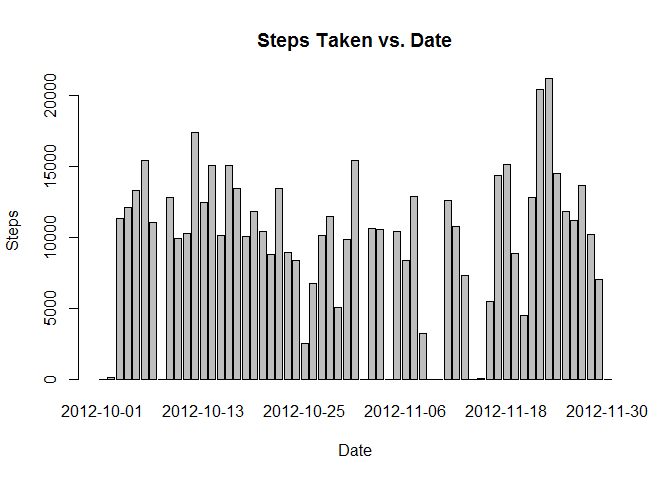

```r
## Aggregate number of steps on dates
dailysteps <-aggregate(actdata$steps, by=list(actdata$date),FUN=sum, na.rm=TRUE)
## Provide appropriate names to columns
colnames(dailysteps)<-c("Date","Steps")
## Plot number of steps vs. dates
barplot(dailysteps$Steps,xlab="Date",ylab="Steps", main="Steps Taken vs. Date",names.arg=dailysteps$Date)
```

2. Calculate and report the mean and median total number of steps taken per day

```r
## Calculate mean of number of steps taken per day
mean(dailysteps$Steps)
```

```
## [1] 9354.23
```

```r
## Calculate median of number of steps taken per day
median(dailysteps$Steps)
```

```
## [1] 10395
```

## What is the average daily activity pattern?

1. Make a time series plot (i.e. type = “l”) of the 5-minute interval (x-axis) and the average number of steps taken, averaged across all days (y-axis)

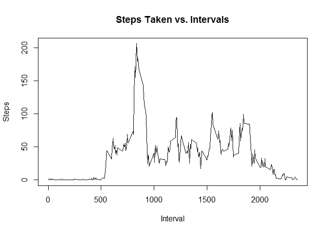

```r
## Average number of steps over intervals
dailyint <-aggregate(actdata$steps, by=list(actdata$interval),FUN=mean, na.rm=TRUE)
## Provide appropriate names to columns
colnames(dailyint)<-c("Interval","Steps")
## Plot average number of steps vs. intervals
plot(dailyint$Interval,dailyint$Steps,type="l",xlab="Interval",ylab="Steps",
        main="Steps Taken vs. Intervals")
```

2. Which 5-minute interval, on average across all the days in the dataset, contains the maximum number of steps?

```r
## Print interval number for max number of steps
dailyint[dailyint$Steps==max(dailyint$Steps),"Interval"]
```

```
## [1] 835
```